# The R Package HDSpatialScan for the Detection of Clusters of Multivariate and Functional Data using Spatial Scan Statistics

## A univariate functional spatial scan statistic

Here we only consider the pollutant $\text{NO}_2$. Applying a spatial scan statistic for univariate functional data will thus allow to highlight areas where the $\text{NO}_2$ concentration curves are abnormally high or, on the contrary abnormally low. We choose to use the URBFSS scan procedure since it often presents higher powers and true positive rates than the other univariate functional methods as its multivariate counterpart MRBFSS (Frévent et al. 2021b). As mentioned in Section 4.2 we decide to use the set of potential clusters *a priori* in the Equation @ref(eq:cluster) which corresponds to the recommended approach of (Martin Kulldorff and Nagarwalla 1995), and to the default values of the parameters `mini`, `maxi` and `type_minimaxi` in the scan functions. We also set a maximum radius equal to 10 km *a posteriori*.

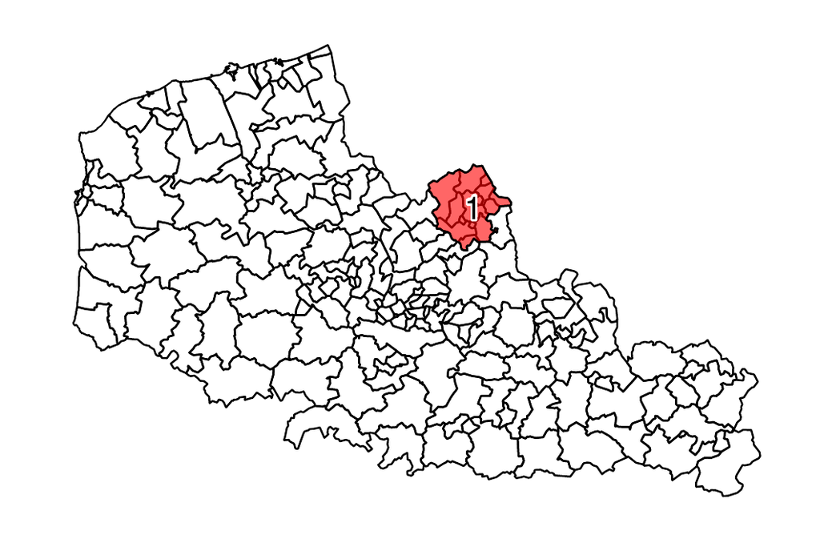

Figure 9: Visualization of the detected clusters with the function `plot` with `type = "map2"` for the URBFSS scan procedure computed using the concentrations of $\text{NO}_2$ in the 169 *cantons* of the *Nord-Pas-de-Calais* region of northern France over the period from May 1, 2020 to June 25, 2020. Here we focus the cluster visualization on the most likely cluster which is located in the urban area of Lille.

```r
 res_urbfss <- SpatialScan(method = "URBFSS", data = funi_data, sites_coord = coords,
 + system = "WGS84", mini = 1, maxi = nrow(coords)/2, type_minimaxi = "sites/indiv",
 + mini_post = 0, maxi_post = 10, type_minimaxi_post = "radius",
 + nbCPU = 7, MC = 99)$URBFSS
 plot(res_urbfss, type = "map2", spobject = map_sites, only.MLC = TRUE)
```

Again the MLC is located in the area of Lille (Figure 9).

For functional data another function is provided to give some characteristics of the clusters: we can visualize the curves in the cluster by adding the curve of the global median with the function `plotCurves`. The function `plotSummary` allows to visualize the median curves inside and outside the cluster (Figure 10): this is a cluster of overexposure to $\text{NO}_2$, which indicates traffic-related air pollution. Since exposure to pollution impacts health negatively, these results can be used to intervene to reduce air pollution.

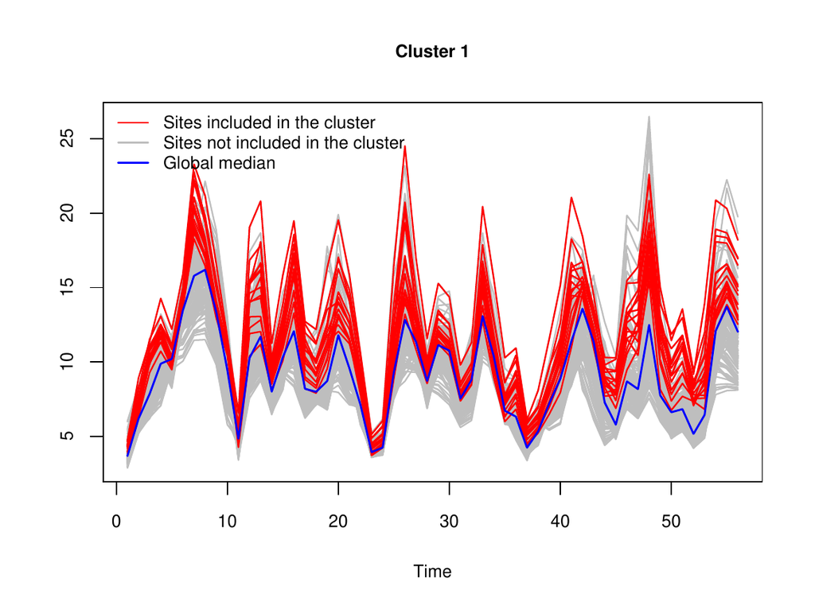

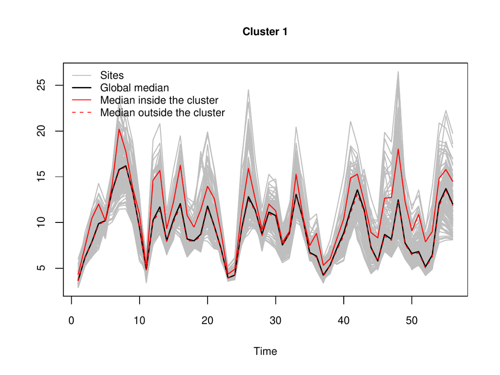

Figure 10: Characterization of the most likely cluster detected by the URBFSS scan approach in the context of univariate functional data consisting of the NO<sub>2</sub> concentrations in northern France over the period from May 1, 2020 to June 25, 2020 with the functions `plotCurves` (left panel) and `plotSummary` (right panel). The most likely cluster is characterized by high concentration curves with a median concentration curve higher than outside the cluster.

```r
 plotCurves(res_urbfss, add_median = TRUE, only.MLC = TRUE)
 plotSummary(res_urbfss, type = "median", only.MLC = TRUE)
```

## A functional multivariate spatial scan statistic

Now we consider the four pollutants together. To detect spatial clusters of the combination of the four pollutants considering all available information on the time period, we apply a spatial scan statistic for multivariate functional data. It will identify geographical areas in which one or more of the pollutant concentration curves are abnormally high or abnormally low. For the same reason that we have previously chosen to apply the URBFSS scan procedure, we use the MRBFSS in this context, with the same restrictions *a priori* and *a posteriori* as for the MNP and the URBFSS scan approaches.

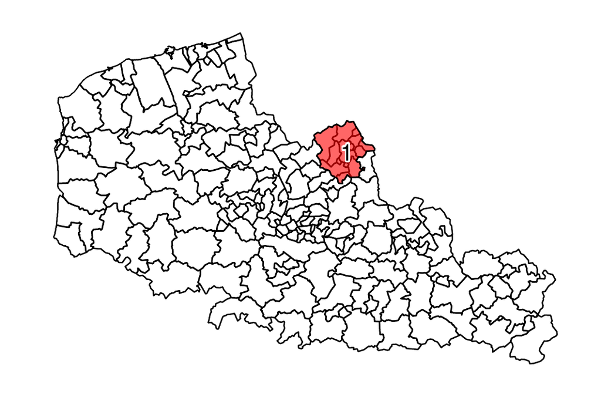

Figure 11: Visualization of the most likely cluster with the function `plot` with `type = "map2"` for the MRBFSS scan procedure computed using the concentrations of $\text{NO}_2$, $\text{O}_3$, $\text{PM}_{10}$ and $\text{PM}_{2.5}$ in the 169 *cantons* of the *Nord-Pas-de-Calais* region of northern France over the period from May 1, 2020 to June 25, 2020. The most likely cluster is located in the urban area of Lille.

```r
 res_mrbfss <- SpatialScan(method = "MRBFSS", data = fmulti_data, sites_coord = coords,
 + system = "WGS84", mini = 1, maxi = nrow(coords)/2, type_minimaxi = "sites/indiv",
 + mini_post = 0, maxi_post = 10, type_minimaxi_post = "radius",
 + nbCPU = 7, MC = 99, variable_names = c("NO2", "O3", "PM10", "PM2.5"))$MRBFSS
 plot(res_mrbfss, type = "map2", spobject = map_sites, only.MLC = TRUE)
```

The detected cluster is exactly the same as before and is therefore located in the urban area of Lille (Figure 11).

Again we will display the curves in the cluster by adding the curve of the global median (Figure 12), as well as the median curves inside and outside the cluster which show that this is a cluster of high concentrations of $\text{NO}_2$, $\text{PM}_{10}$ and $\text{PM}_{2.5}$ (Figure 13). As mentioned in Section 4.2, in environmental science it is well-known that $\text{NO}_2$ and $\text{PM}_{2.5}$ are more frequent in urban areas due to road traffic and population density so this is consistent with the cluster observed here. As the adverse health effects of air pollution and the combined effects of air pollutants are well established, this result could enable interventions by local authorities around the Lille area to reduce air pollution.

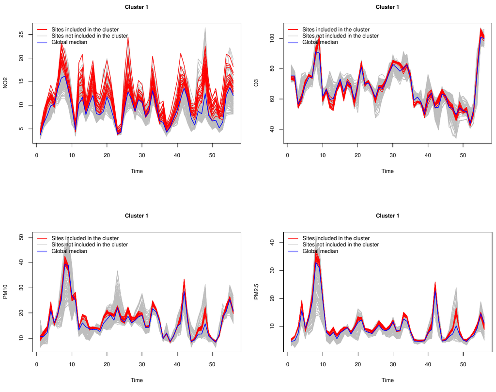

Figure 12: Characterization of the most likely cluster detected by the MRBFSS scan approach in the context of multivariate functional data consisting of the $\text{NO}_2$, $\text{O}_3$, $\text{PM}_{10}$ and $\text{PM}_{2.5}$ concentrations in northern France over the period from May 1, 2020 to June 25, 2020 with the function `plotCurves`. The most likely cluster is characterized by high concentration curves of $\text{NO}_2$, $\text{PM}_{10}$ and $\text{PM}_{2.5}$.

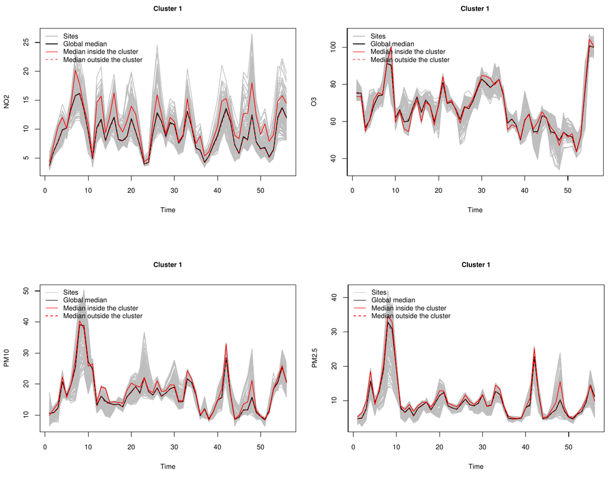

Figure 13: Characterization of the most likely cluster detected by the MRBFSS scan approach in the context of multivariate functional data consisting of the $\text{NO}_2$, $\text{O}_3$, $\text{PM}_{10}$ and $\text{PM}_{2.5}$ concentrations in northern France over the period from May 1, 2020 to June 25, 2020 with the function `plotSummary`. The most likely cluster is characterized by median concentration curves of $\text{NO}_2$, $\text{PM}_{10}$ and $\text{PM}_{2.5}$ higher than outside the cluster.

```r
 plotCurves(res_mrbfss, add_median = TRUE, only.MLC = TRUE)
 plotSummary(res_mrbfss, type = "median", only.MLC = TRUE)
```

# Summary

In this article we presented the *HDSpatialScan* package. It makes it very easy to apply the existing scan statistics developed for multivariate data or functional data (univariate or multivariate), and the new rank-based scan statistic for univariate functional data presented in the Section 2. The potential clusters considered are of variable size and circular. In further updates of the package *HDSpatialScan* other shapes of scanning window such as elliptical or rectangular shapes will be implemented. Our package also allows to easily plot and summarize the detected clusters. Then examples of applications of the functions of the package have been shown. *HDSpatialScan* presents the advantage that all the scan procedures are applied using the same function `SpatialScan` and it uses the classical R functions `plot`, `print` and `summary` which makes it very quick to get started.

Allévius, Benjamin. 2018a. *Scanstatistics: Space-Time Anomaly Detection Using Scan Statistics*. https://CRAN.R-project.org/package=scanstatistics.

———. 2018b. “Scanstatistics: Space-Time Anomaly Detection Using Scan Statistics.” *Journal of Open Source Software* 3. https://doi.org/10.21105/joss.00515.

Berrendero, J. R., Ana Justel, and Marcela Svarc. 2011. “Principal Components for Multivariate Functional Data.” *Computational Statistics & Data Analysis* 55: 2619–34. https://doi.org/10.1016/j.csda.2011.03.011.

Bhatt, Vijaya, and Neeraj Tiwari. 2014. “A Spatial Scan Statistic for Survival Data Based on Weibull Distribution.” *Statistics in Medicine* 33 (11): 1867–76. https://doi.org/10.1002/sim.6075.

Boente, Graciela, and Ricardo Fraiman. 2000. “Kernel-Based Functional Principal Components.” *Statistics & Probability Letters* 48: 335–45. https://doi.org/10.1016/S0167-7152(00)00014-6.

Chakraborty, Anirvan, and Probal Chaudhuri. 2014. “A Wilcoxon-Mann-Whitney Type Test for Infinite Dimensional Data.” *Biometrika* 102. https://doi.org/10.1093/biomet/asu072.

Chen, Cici, Albert Y. Kim, Michelle Ross, and Jon Wakefield. 2018. *SpatialEpi: Methods and Data for Spatial Epidemiology*. https://CRAN.R-project.org/package=SpatialEpi.

Chiou, Jeng-Min, and Hans-Georg Müller. 2007. “Diagnostics for Functional Regression via Residual Processes.” *Computational Statistics & Data Analysis* 15 (June): 4849–63. https://doi.org/10.1016/j.csda.2006.07.042.

Cucala, Lionel. 2014. “A Distribution-Free Spatial Scan Statistic for Marked Point Processes.” *Spatial Statistics* 10: 117–25. https://doi.org/10.1016/j.spasta.2014.03.004.

———. 2016. “A Mann-Whitney Scan Statistic for Continuous Data.” *Communications in Statistics-Theory and Methods* 45 (2): 321–29. https://doi.org/10.1080/03610926.2013.806667.

Cucala, Lionel, Christophe Demattei, Paulo Lopes, and Andre Ribeiro. 2013. “A Spatial Scan Statistic for Case Event Data Based on Connected Components.” *Computational Statistics* 28 (1): 357–69. https://doi.org/10.1007/s00180-012-0304-6.

Cucala, Lionel, Michael Genin, Caroline Lanier, and Florent Occelli. 2017. “A Multivariate Gaussian Scan Statistic for Spatial Data.” *Spatial Statistics* 21: 66–74. https://doi.org/10.1016/j.spasta.2017.06.001.

Cucala, Lionel, Michaël Genin, Florent Occelli, and Julien Soula. 2019. “A Multivariate Nonparametric Scan Statistic for Spatial Data.” *Spatial Statistics* 29: 1–14. https://doi.org/10.1016/j.spasta.2018.10.002.

Cuevas, Antonio, Manuel Febrero-Bande, and Ricardo Fraiman. 2002. “Linear Functional Regression: The Case of Fixed Design and Functional Response.” *The Canadian Journal of Statistics* 30: 285–300. https://doi.org/10.2307/3315952.

———. 2004. “An ANOVA Test for Functional Data.” *Computational Statistics & Data Analysis* 47: 111–22. https://doi.org/10.1016/j.csda.2003.10.021.

Dematteı̈, Christophe, Nicolas Molinari, and Jean-Pierre Daurès. 2006. “SPATCLUS: An R Package for Arbitrarily Shaped Multiple Spatial Cluster Detection for Case Event Data.” *Computer Methods and Programs in Biomedicine* 84 (1): 42–49. https://doi.org/10.1016/j.cmpb.2006.07.008.

Durbeck, H., D. Greiling, L. Estberg, A. Long, G. Jacquez, Y. Pallicaris, and S. Hinton. 2012. *ClusterSeer: Software for the Detection and Analysis of Event Clusters, User Manual Book 2, Version 2.5*. BioMedware.

Dwass, Meyer. 1957. “Modified Randomization Tests for Nonparametric Hypotheses.” *The Annals of Mathematical Statistics* 28 (1): 181–87. https://doi.org/10.1214/aoms/1177707045.

Ferraty, Frederic, and Philippe Vieu. 2002. “The Functional Nonparametric Model and Application to Spectrometric Data.” *Computational Statistics* 17: 545–64. https://doi.org/10.1007/s001800200126.

Frévent, Camille, Mohamed-Salem Ahmed, Sophie Dabo-Niang, and Michaël Genin. 2021b. “Investigating Spatial Scan Statistics for Multivariate Functional Data.”

Frévent, Camille, Mohamed-Salem Ahmed, Matthieu Marbac, and Michaël Genin. 2021a. “Detecting Spatial Clusters in Functional Data: New Scan Statistic Approaches.” *Spatial Statistics*, 2021a, 100550. https://doi.org/10.1016/j.spasta.2021.100550.

Gao, Jie, Zhijie Zhang, Yi Hu, Jianchao Bian, Wen Jiang, Xiaoming Wang, Liqian Sun, and Qingwu Jiang. 2014. “Geographical Distribution Patterns of Iodine in Drinking-Water and Its Associations with Geological Factors in Shandong Province, China.” *International Journal of Environmental Research and Public Health* 11 (5): 5431–44. https://doi.org/10.3390/ijerph110505431.

Genin, Michaël, Mathurin Fumery, Florent Occelli, Guillaume Savoye, Benjamin Pariente, Luc Dauchet, Jonathan Giovannelli, et al. 2020. “Fine-Scale Geographical Distribution and Ecological Risk Factors for Crohn’s Disease in France (2007-2014).” *Alimentary Pharmacology & Therapeutics* 51 (1): 139–48. https://doi.org/10.1111/apt.15512.

Gomez-Rubio, Virgilio, Paula Esther Moraga Serrano, and Barry Rowlingson. 2020. *DClusterm: Model-Based Detection of Disease Clusters*. https://CRAN.R-project.org/package=DClusterm.

Gómez-Rubio, Virgilio, Juan Ferrándiz-Ferragud, and Antonio López-Quı́lez. 2015. *DCluster: Functions for the Detection of Spatial Clusters of Diseases*. https://CRAN.R-project.org/package=DCluster.

Gómez-Rubio, Virgilio, Paula Moraga, John Molitor, and Barry Rowlingson. 2019. “DClusterm: Model-Based Detection of Disease Clusters.” *Journal of Statistical Software* 90 (14): 1–26. https://doi.org/10.18637/jss.v090.i14.

Górecki, Tomasz, and Łukasz Smaga. 2015. “A Comparison of Tests for the One-Way ANOVA Problem for Functional Data.” *Computational Statistics* 30: 987–1010. https://doi.org/10.1007/s00180-015-0555-0.

———. 2017. “Multivariate Analysis of Variance for Functional Data.” *Journal of Applied Statistics* 44 (12): 2172–89. https://doi.org/10.1080/02664763.2016.1247791.

Greiling, D., L. Estberg, A. Long, and G. Jacquez. 2012. *ClusterSeer: Software for the Detection and Analysis of Event Clusters, User Manual Book 1, Version 2.5*. BioMedware.

Huang, Lan, Martin Kulldorff, and David Gregorio. 2007. “A Spatial Scan Statistic for Survival Data.” *Biometrics* 63 (1): 109–18. https://doi.org/10.1111/j.1541-0420.2006.00661.x.

Jung, Inkyung, and Ho Jin Cho. 2015. “A Nonparametric Spatial Scan Statistic for Continuous Data.” *International Journal of Health Geographics* 14. https://doi.org/10.1186/s12942-015-0024-6.

Jung, Inkyung, Martin Kulldorff, and Ann C Klassen. 2007. “A Spatial Scan Statistic for Ordinal Data.” *Statistics in Medicine* 26 (7): 1594–1607. https://doi.org/10.1002/sim.2607.

Khan, Md Marufuzzaman, Shamarial Roberson, Keshia Reid, Melissa Jordan, and Agricola Odoi. 2021. “Geographic Disparities and Temporal Changes of Diabetes Prevalence and Diabetes Self-Management Education Program Participation in Florida.” *Plos One* 16 (7). https://doi.org/10.1371/journal.pone.0254579.

Kleinman, Ken. 2015. *Rsatscan: Tools, Classes, and Methods for Interfacing with SaTScan Stand-Alone Software*. https://CRAN.R-project.org/package=rsatscan.

Kulldorff, Martin. 1997. “A Spatial Scan Statistic.” *Communications in Statistics - Theory and Methods* 26: 1481–96. https://doi.org/10.1080/03610929708831995.

———. 2018. *TreeScan User Guide*. https://www.treescan.org/.

———. 2021. *SaTScan User Guide for Version 9.7*. https://www.satscan.org/.

Kulldorff, Martin, Zixing Fang, and Stephen J. Walsh. 2003. “A Tree-Based Scan Statistic for Database Disease Surveillance.” *Biometrics* 59 (2): 323–31. https://doi.org/10.1111/1541-0420.00039.

Kulldorff, Martin, Lan Huang, and Kevin Konty. 2009. “A Scan Statistic for Continuous Data Based on the Normal Probability Model.” *International Journal of Health Geographics* 8 (58). https://doi.org/10.1186/1476-072X-8-58.

Kulldorff, Martin, Lan Huang, Linda Pickle, and Luiz Duczmal. 2006. “An Elliptic Spatial Scan Statistic.” *Statistics in Medicine* 25: 3929–43. https://doi.org/10.1002/sim.2490.

Kulldorff, Martin, Farzad Mostashari, Luiz Duczmal, W Katherine Yih, Ken Kleinman, and Richard Platt. 2007. “Multivariate Scan Statistics for Disease Surveillance.” *Statistics in Medicine* 26: 1824–33. https://doi.org/10.1002/sim.2818.

Kulldorff, Martin, and Neville Nagarwalla. 1995. “Spatial Disease Clusters: Detection and Inference.” *Statistics in Medicine* 14 (8): 799–810. https://doi.org/10.1002/sim.4780140809.

Kulldorff, M., WF Athas, EJ Feurer, BA Miller, and CR Key. 1998. “Evaluating Cluster Alarms: A Space-Time Scan Statistic and Brain Cancer in Los Alamos, New Mexico.” *The American Journal of Public Health* 88 (9): 1377–80. https://doi.org/10.2105/AJPH.88.9.1377.

Lin, Zhenhua, Miles E. Lopes, and Hans-Georg Müller. 2021. “High-Dimensional MANOVA via Bootstrapping and Its Application to Functional and Sparse Count Data.” *Journal of the American Statistical Association*. https://doi.org/10.1080/01621459.2021.1920959.

Loche, Robin, Benoit Giron, David Abrial, Lionel Cucala, Myriam CharrasGarrido, and Jocelyn De-Goer. 2016. *Graphscan: Cluster Detection with Hypothesis Free Scan Statistic*. https://CRAN.R-project.org/package=graphscan.

Marciano, Lucia Helena Soares Camargo, Andréa de Faria Fernandes Belone, Patrı́cia Sammarco Rosa, Neusa Maria Broch Coelho, Cássio César Ghidella, Susilene Maria Tonelli Nardi, William Cabral Miranda, Ligia Vizeu Barrozo, and Joel Carlos Lastória. 2018. “Epidemiological and Geographical Characterization of Leprosy in a Brazilian Hyperendemic Municipality.” *Cadernos de Saude Publica* 34. https://doi.org/10.1590/0102-311X00197216.

Moraga, Paula. 2017a. “SpatialEpiApp: A Shiny Web Application for the Analysis of Spatial and Spatio-Temporal Disease Data.” *Spatial and Spatio-Temporal Epidemiology* 23. https://doi.org/10.1016/j.sste.2017.08.001.

———. 2017b. *SpatialEpiApp: A Shiny Web Application for the Analysis of Spatial and Spatio-Temporal Disease Data*. https://CRAN.R-project.org/package=SpatialEpiApp.

Oja, Hannu, and Ronald H. Randles. 2004. “Multivariate Nonparametric Tests.” *Statistical Science* 18 (4): 598–605. https://doi.org/10.1214/088342304000000558.

Otani, T., and K. Takahashi. 2021. *Rflexscan: The Flexible Spatial Scan Statistic*. https://CRAN.R-project.org/package=rflexscan.

PROJ contributors. 2021. *PROJ Coordinate Transformation Software Library*. Open Source Geospatial Foundation. https://proj.org/.

Qiu, Zhiping, Jianwei Chen, and Jin-Ting Zhang. 2021. “Two-Sample Tests for Multivariate Functional Data with Applications.” *Computational Statistics & Data Analysis* 157. https://doi.org/10.1016/j.csda.2020.107160.

Ramsay, J. O., Spencer Graves, and Giles Hooker. 2020. *Fda: Functional Data Analysis*. https://CRAN.R-project.org/package=fda.

Ramsay, JO, and BW Silverman. 2005. *Functional Data Analysis*. Springer Series in Statistics. Springer-Verlag.

Shi, Guiqian, Jiaxiu Liu, and Xiaoni Zhong. 2021. “Spatial and Temporal Variations of $\text{PM}_{2.5}$ Concentrations in Chinese Cities During 2015-2019.” *International Journal of Environmental Health Research*, 1–13. https://doi.org/10.1080/09603123.2021.1987394.

Smida, Zaineb, Lionel Cucala, Ali Gannoun, and Ghislain Durif. 2022. “A Wilcoxon-Mann-Whitney Spatial Scan Statistic for Functional Data.” *Computational Statistics & Data Analysis* 167: 107378. https://doi.org/10.1016/j.csda.2021.107378.

Sudakin, Daniel L, Zane Horowitz, and Sandy Giffin. 2002. “Regional Variation in the Incidence of Symptomatic Pesticide Exposures: Applications of Geographic Information Systems.” *Journal of Toxicology: Clinical Toxicology* 40 (6): 767–73. https://doi.org/10.1081/CLT-120015837.

Takahashi, Kunihiko, and Toshiro Tango. 2005. “A Flexibly Shaped Spatial Scan Statistic for Detecting Clusters.” *International Journal of Health Geographics* 4 (11). https://doi.org/10.1186/1476-072X-4-11.

Takahashi, Kunihiko, Tetsuji Yokoyama, and Toshiro Tango. 2010. *FleXScan v 3.1: Software for the Flexible Scan Statistic*.

Wan, Liangtian, Yuchen Sun, Ivan Lee, Wenhong Zhao, and Feng Xia. 2020. “Industrial Pollution Areas Detection and Location via Satellite-Based IIoT.” *IEEE Transactions on Industrial Informatics* 17 (3): 1785–94. https://doi.org/10.1109/TII.2020.2992658.